Let us initiate our discussion by considering the following categories: the count of extant species currently inhabiting the world, those species that have ceased to exist, and the quantity of species for which data validation remains pending.

```
Number of species still present in the world are :  83278
Number of species whose status is not confirmed are :  11958
Number of species who are not longer present in the world are :  1310
```

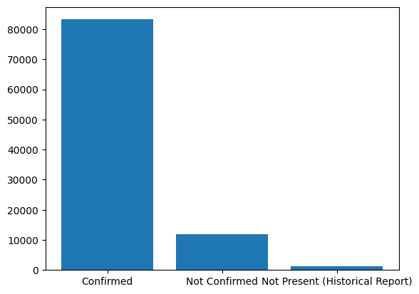

```python
import pandas as pd
import matplotlib.pyplot as mypy

df=pd.read_csv('./species.csv')

# Use the `value_counts()` method to count the occurrences of each unique value in the "Score" column
total_values = df['Occurrence'].value_counts()

# Check if "Present," "Not confirmed," and "Not Present (Historical Report)" are present in the index of the result
# If any of them is not present, set the count to 0
count_present = total_values.get('Present', 0)
count_not_confirmed = total_values.get('Not Confirmed', 0)
count_not_present= total_values.get('Not Present (Historical Report)', 0)

print("Number of species still present in the world are : ", count_present)
print("Number of species whose status is not confirmed are : ", count_not_confirmed)
print("Number of species who are not longer present in the world are : ", count_not_present)

x=['Confirmed','Not Confirmed','Not Present (Historical Report)']
y=[count_present,count_not_confirmed,count_not_present]

mypy.bar(x,y)
mypy.show()
```

```python
parks = pd.read_csv("./species.csv")
species = pd.read_csv("./species.csv")
species
```

|  | Species ID | Park Name | Category | Order | Family | Scientific Name | Common Names | Record Status | Occurrence | Nativeness | Abundance | Seasonality | Conservation Status | Unnamed: 13 |
| --- | --- | --- | --- | --- | --- | --- | --- | --- | --- | --- | --- | --- | --- | --- |
| 0 | ACAD-1000 | Acadia National Park | Mammal | Artiodactyla | Cervidae | Alces alces | Moose | Approved | Present | Native | Rare | Resident | NaN | NaN |
| 1 | ACAD-1001 | Acadia National Park | Mammal | Artiodactyla | Cervidae | Odocoileus virginianus | Northern White-Tailed Deer, Virginia Deer, Whi... | Approved | Present | Native | Abundant | NaN | NaN | NaN |
| 2 | ACAD-1002 | Acadia National Park | Mammal | Carnivora | Canidae | Canis latrans | Coyote, Eastern Coyote | Approved | Present | Not Native | Common | NaN | Species of Concern | NaN |
| 3 | ACAD-1003 | Acadia National Park | Mammal | Carnivora | Canidae | Canis lupus | Eastern Timber Wolf, Gray Wolf, Timber Wolf | Approved | Not Confirmed | Native | NaN | NaN | Endangered | NaN |
| 4 | ACAD-1004 | Acadia National Park | Mammal | Carnivora | Canidae | Vulpes vulpes | Black Fox, Cross Fox, Eastern Red Fox, Fox, Re... | Approved | Present | Unknown | Common | Breeder | NaN | NaN |
| ... | ... | ... | ... | ... | ... | ... | ... | ... | ... | ... | ... | ... | ... | ... |
| 119243 | ZION-2791 | Zion National Park | Vascular Plant | Solanales | Solanaceae | Solanum triflorum | Cut-Leaf Nightshade | Approved | Present | Native | Uncommon | NaN | NaN | NaN |
| 119244 | ZION-2792 | Zion National Park | Vascular Plant | Vitales | Vitaceae | Vitis arizonica | Canyon Grape | Approved | Present | Native | Uncommon | NaN | NaN | NaN |
| 119245 | ZION-2793 | Zion National Park | Vascular Plant | Vitales | Vitaceae | Vitis vinifera | Wine Grape | Approved | Present | Not Native | Uncommon | NaN | NaN | NaN |
| 119246 | ZION-2794 | Zion National Park | Vascular Plant | Zygophyllales | Zygophyllaceae | Larrea tridentata | Creosote Bush | Approved | Present | Native | Rare | NaN | NaN | NaN |
| 119247 | ZION-2795 | Zion National Park | Vascular Plant | Zygophyllales | Zygophyllaceae | Tribulus terrestris | Puncture Vine | Approved | Present | Not Native | Uncommon | NaN | NaN | NaN |

119248 rows × 14 columns

Exploration

```python
df = pd.crosstab(species['Category'], species['Conservation Status'])
df
```

| Conservation Status Category | Breeder | Endangered | Extinct | In Recovery | Migratory | Proposed Endangered | Proposed Threatened | Resident | Species of Concern | Threatened | Under Review |
| --- | --- | --- | --- | --- | --- | --- | --- | --- | --- | --- | --- |
| Amphibian | 0 | 5 | 0 | 0 | 0 | 0 | 0 | 0 | 61 | 8 | 26 |
| Bird | 4 | 64 | 0 | 65 | 0 | 2 | 0 | 4 | 2371 | 51 | 70 |
| Crab/Lobster/Shrimp | 0 | 1 | 0 | 0 | 0 | 0 | 0 | 0 | 0 | 0 | 1 |
| Fish | 1 | 33 | 1 | 0 | 0 | 0 | 0 | 0 | 66 | 40 | 10 |
| Fungi | 0 | 1 | 0 | 0 | 0 | 0 | 0 | 0 | 2 | 0 | 1 |
| Insect | 0 | 17 | 0 | 0 | 0 | 1 | 0 | 0 | 107 | 4 | 12 |
| Invertebrate | 0 | 9 | 0 | 0 | 0 | 0 | 0 | 0 | 1 | 7 | 4 |
| Mammal | 1 | 93 | 0 | 9 | 2 | 0 | 3 | 0 | 552 | 19 | 1 |
| Nonvascular Plant | 0 | 0 | 0 | 0 | 0 | 0 | 0 | 0 | 27 | 0 | 4 |
| Reptile | 1 | 17 | 0 | 1 | 0 | 0 | 2 | 1 | 98 | 17 | 16 |
| Slug/Snail | 0 | 5 | 0 | 0 | 0 | 0 | 0 | 0 | 21 | 1 | 13 |
| Spider/Scorpion | 0 | 1 | 0 | 0 | 0 | 0 | 0 | 0 | 0 | 0 | 0 |
| Vascular Plant | 0 | 128 | 0 | 2 | 0 | 21 | 2 | 0 | 537 | 37 | 36 |

The term 'Species of Concern' is an informal designation used by a region to identify species that may require concentrated conservation efforts. The specific conservation actions undertaken vary according to the health of the populations and the types and levels of threats faced. At one end of the spectrum, these actions may entail periodic monitoring of species populations and associated threats to their habitats. At the other end, a species may warrant designation as a federally recognized threatened or endangered species. It is essential to note that species labeled as 'Species of Concern' do not receive legal protection, and the use of this term does not necessarily indicate that a species will eventually be proposed for listing as threatened or endangered.

The graph presented below illustrates that our primary focus should be on addressing species of greatest concern, particularly those categorized as 'endangered.' Among these, the categories of birds, mammals, and vascular plants feature a notable number of endangered speci.es

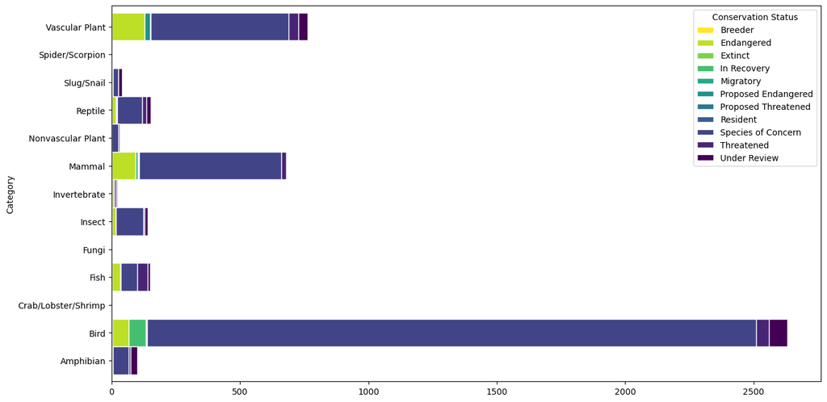

```python
df.plot.barh(stacked=True, figsize=[15,8],
             edgecolor='white',
             width=1,
             colormap='viridis_r')
```

To begin our analysis, we have concentrated on the available data pertaining to mammals. Let us focus on determining which Families/Order are on endangered status.

```python
mammal = species[species['Category']=='Mammal']
mammal_df = pd.crosstab(mammal['Order'], mammal['Conservation Status'], margins=True)
mammal_df.head()
```

| Conservation Status Order | Breeder | Endangered | In Recovery | Migratory | Proposed Threatened | Species of Concern | Threatened | Under Review | All |
| --- | --- | --- | --- | --- | --- | --- | --- | --- | --- |
| Artiodactyla | 0 | 2 | 0 | 1 | 0 | 25 | 1 | 1 | 30 |
| Carnivora | 0 | 37 | 7 | 1 | 3 | 105 | 7 | 0 | 160 |
| Cetacea | 0 | 38 | 2 | 0 | 0 | 0 | 0 | 0 | 40 |
| Chiroptera | 0 | 11 | 0 | 0 | 0 | 399 | 10 | 0 | 420 |
| Lagomorpha | 0 | 0 | 0 | 0 | 0 | 5 | 0 | 0 | 5 |

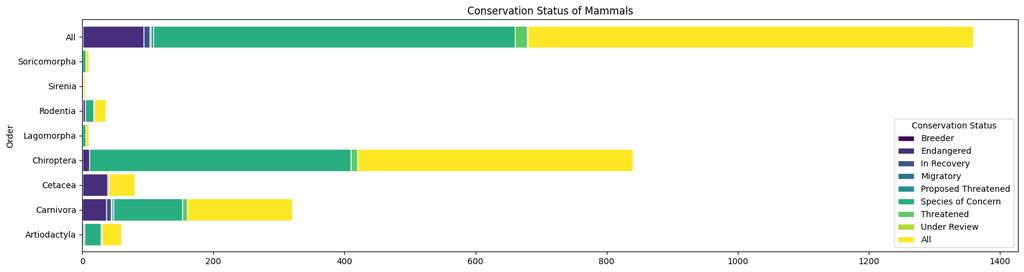

```python
mammal_df.plot.barh(stacked=True,
                    figsize=[20,5],
                    colormap='viridis',
                    edgecolor='white',
                    width=0.9,
                    title='Conservation Status of Mammals')
```